# Kling on to the Government

Zack Wixom

10/19/20

### The Current Rule

Over the past 60 years, we have seen ebbs and flows to our unemployment rate. Within the last few years the unemployment rate as skyrocketed and as a major factor for a our growing economy, we need to understand what may be causing this blight and how to stop it. Romulans have predominantly controlled the government for the last 60 years, has their political campaigns and agendas fueled the socio-economic unrest?

### Initial Findings

Using employment data sources provided by the ambassador from Earth, **Jeff Parker**, I have uncovered interesting insights into each political parties control and the employment repercussions. First, I viewed the overall unemployment rate over the last 60 years of data and which party was predominantly in control; *in control is defined as having 2 branches of government with majority in the party*.

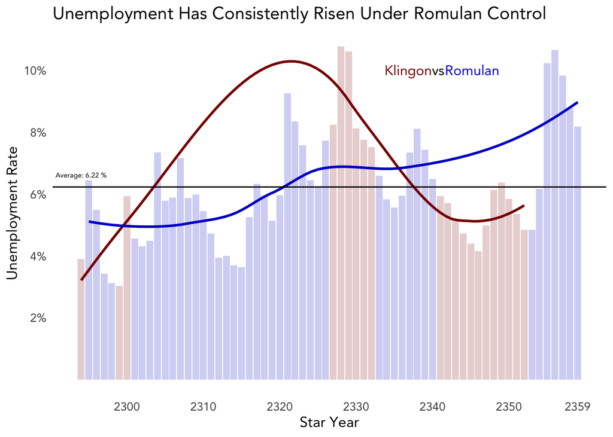

```r
# Calculate Overall Average
overall_average <- mean(party_control$`Unemp/Emp Ratio`)

# When two seats have been filled by Klingon
K_control <- party_control %>%
  filter(President == "K" & Senate == "K" | President == "K" & House == "K" | House == "K" & Senate == "K")

# Klingon Average Unemployment Rate
K_average <- mean(K_control$`Unemp/Emp Ratio`)

# When two seats have been filled by Romulan
R_control <- party_control %>%
  filter(President == "R" & Senate == "R" | President == "R" & House == "R" | House == "R" & Senate == "R")

# Romulan Average Unemployment Rate
R_average <- mean(R_control$`Unemp/Emp Ratio`)

ggplot() +
  # Plot K and R data
  geom_col(data = K_control, aes(x = `Star Year`, y=`Unemp/Emp Ratio`), fill = "#8b0000", alpha = 0.2) +
  geom_col(data = R_control, aes(x = `Star Year`, y=`Unemp/Emp Ratio`), fill = "#0000CD", alpha = 0.2) +
  geom_smooth(data = K_control, aes(x = `Star Year`, y=`Unemp/Emp Ratio`), color = "#8b0000", method = "loess",se = FALSE) +
  geom_smooth(data = R_control, aes(x = `Star Year`, y=`Unemp/Emp Ratio`), color = "#0000CD", method = "loess", se = FALSE) +
  # Modify Theme
  theme_minimal() +
  theme(
    plot.background = element_blank(),
    panel.background = element_blank(),
    panel.grid = element_blank(),
    panel.border = element_blank(),
    text = element_text(family = "Avenir", size = 12),
    axis.ticks = element_blank(),
    legend.position = "none"
  ) +
  # Average Unemployment Rate
  geom_hline(yintercept = overall_average) +
  # Add Text to Graph
  geom_text(aes(2294, overall_average,label = paste("Average:", 100 * round(overall_average,4), "%"), vjust = -2),
            family = "Avenir",
            size = 2) +
  geom_text(aes(2330, .1, label = "Klingon", hjust = -.60),
            family = "Avenir",
            size = 4,
            color = "#8b0000") +
  geom_text(aes(2335, .1, label = "vs", hjust = -3),
            family = "Avenir",
            size = 4) +
  geom_text(aes(2340, .1, label = "Romulan", hjust = -.23),
            family = "Avenir",
            size = 4,
            color = "#0000CD") +
  # labels
  labs(
    title = "Unemployment Has Consistently Risen Under Romulan Control",
    y = "Unemployment Rate"
  ) +
  # Fix Scales
  scale_y_continuous(labels = scales::percent_format(accuracy = 1), breaks = c(.02, .04, .06,.08, .1)) +
  scale_x_continuous(breaks = c(2300,2310, 2320, 2330, 2340, 2350, 2359))
```

### Deeper Dive

There are many ups and downs of unemployment during each parties rule, however, I dove deeper into the most recent years to figure out what how each party is influencing the deltas of employment and unemployment. Klingon control has shown positive delta’s in employment rate — **higher number of citizens employment**. Complementing their negative delta’s in unemployment — **lower number of citizens unemployment**.

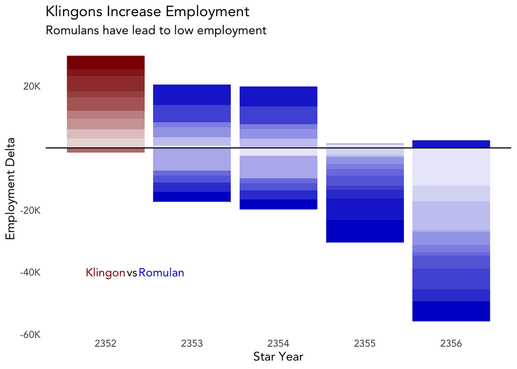

```r
# When two seats have been filled by Klingon
K_sample <- monthly_sample %>%
  filter(President == "K" & Senate == "K" | President == "K" & House == "K" | House == "K" & Senate == "K")

# When two seats have been filled by Romulan
R_sample <- monthly_sample %>%
  filter(President == "R" & Senate == "R" | President == "R" & House == "R" | House == "R" & Senate == "R")

# Plot Employment Delta
ggplot() +
  # Plot K and R data
  geom_col(data = K_sample, aes(x = `Star Year`, y= `Employment Delta`, alpha = `Star Month`), fill = "#8b0000") +
  geom_col(data = R_sample, aes(x = `Star Year`, y=`Employment Delta`, alpha = `Star Month`), fill = "#0000CD") +
  # Modify Theme
  theme_minimal() +
  theme(
    plot.background = element_blank(),
    panel.background = element_blank(),
    panel.grid = element_blank(),
    panel.border = element_blank(),
    text = element_text(family = "Avenir", size = 12),
    axis.ticks = element_blank(),
    legend.position = "none"
  ) +
  # Add Additional Elements
  geom_hline(yintercept = 0) +
  geom_text(aes(2352, -4000, label = "Klingon"),
            family = "Avenir",
            size = 4,
            color = "#8b0000") +
  geom_text(aes(2352, -4000, label = "vs", hjust = -2),
            family = "Avenir",
            size = 4) +
  geom_text(aes(2352, -4000, label = "Romulan", hjust = -.72),
            family = "Avenir",
            size = 4,
            color = "#0000CD") +
  # Fix Scales
  scale_y_continuous(labels = scales::label_number(suffix = "K", scale = 1/1e2), breaks = c(-6000, -4000, -2000, 2000)) +
  # labels
  labs(
    title = "Klingons Increase Employment",
    subtitle = "Romulans have lead to low employment"
  )
```

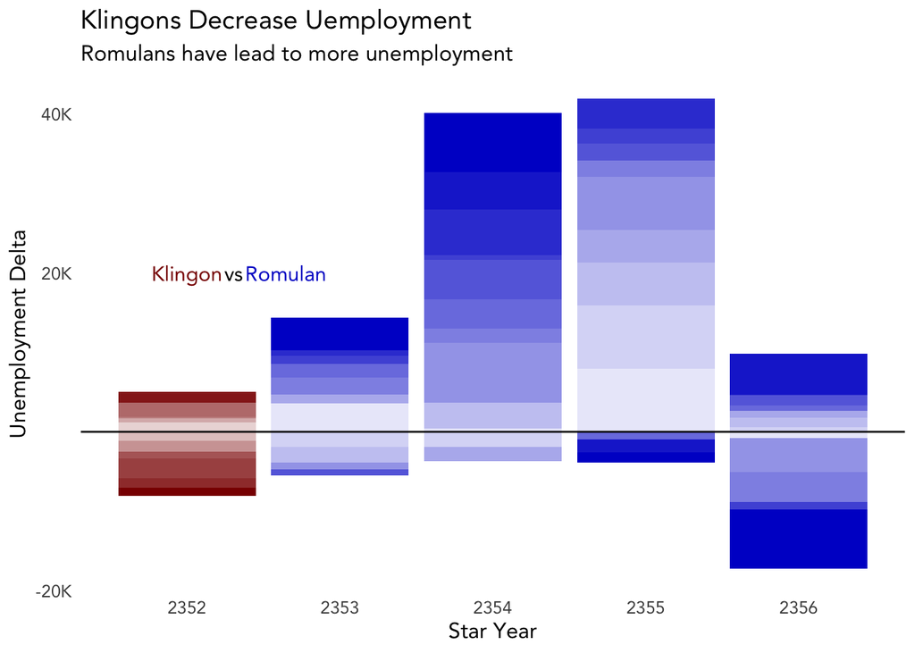

```r
# Plot Unemployment Delta
ggplot() +
  geom_col(data = K_sample, aes(x = `Star Year`, y= `Unemployment Delta`, alpha = `Star Month`), fill = "#8b0000" ) +
  geom_col(data = R_sample, aes(x = `Star Year`, y=`Unemployment Delta`, alpha = `Star Month`), fill = "#0000CD") +
  # xlim(2310, 2360) +
    # Modify Theme
  theme_minimal() +
  theme(
    plot.background = element_blank(),
    panel.background = element_blank(),
    panel.grid = element_blank(),
    panel.border = element_blank(),
    text = element_text(family = "Avenir", size = 12),
    axis.ticks = element_blank(),
    legend.position = "none"
  ) +
  # Add Additional Elements
  geom_hline(yintercept = 0) +
  geom_text(aes(2352, 2000, label = "Klingon"),
            family = "Avenir",
            size = 4,
            color = "#8b0000") +
  geom_text(aes(2352, 2000, label = "vs", hjust = -2),
            family = "Avenir",
            size = 4) +
  geom_text(aes(2352, 2000, label = "Romulan", hjust = -.72),
            family = "Avenir",
            size = 4,
            color = "#0000CD") +
  # Fix Scales
  scale_y_continuous(labels = scales::label_number(suffix = "K", scale = 1/1e2), breaks = c(-2000, 2000, 4000)) +
  # labels
  labs(
    title = "Klingons Decrease Uemployment",
    subtitle = "Romulans have lead to more unemployment"
  )
```

### Conclusion

Despite their under representation in the government, Klingon’s have consistently sought for a better community and world while in control. Voters should understand the socio-economic impact of each party and act accordingly if we want our world to be a successful in the galaxy. We must **Kling On To The Government!**